# Dimension Reduction

#### Unsupervied Learning 2020/2021 Winter - Dimension Reduction Final Project

#### 436823

## DIMENSION REDUCTION: PCA ANALYSIS ON IMAGE COMPRESSION

### Dimension Reduction

Dimensions refer the number of input variables or features for a dataset. It can be columns or an array of points that make up a large sphere in the three-dimensional space. Dimension reduction refers to techniques that reduce the number of input variables in a dataset.

More features often make a predictive modeling task more challenging to model, more generally referred to as the curse of dimensionality. In other words, as the number of features increase, the number of samples also increases. The more features we have, the more number of samples we will need to have all combinations of feature values well represented in our sample. Therefore, it is often desirable to reduce the number of input features.

### Principal Component Analysis (PCA)

Principal component analysis is one of the methods that can be used in dimension reduction. It is a statistical procedure to convert observations of possibly correlated features into *Principal Components*.

### Using PCA for Image Compression

An image can be treated as a matrix - a grid of pixels, with values being the pixel intensities. Steps should follow as:

- Applying PCA on the image matrix to reduce the dimensionality to a smaller number of principal components.
- Reconstructing the image from the limited number of principal components in order to assess how much visual information retained.
- Checking how good the reconstructed images are for different number of selected components.

```python
import numpy as np
from matplotlib.image import imread
import matplotlib.pyplot as plt
from sklearn.decomposition import PCA, IncrementalPCA
import cv2
```

### Data

The example image that is used in the analysis is a picture of Royal Albert Dock in Liverpool, taken by me in 2018.

```python
## Reading the image

image = imread(r'C:\Users\Gamze\Desktop\USL\2- Dimension Reduction\Liverpool.jpg')
print(image.shape)
```

```
(2791, 4103, 3)
```

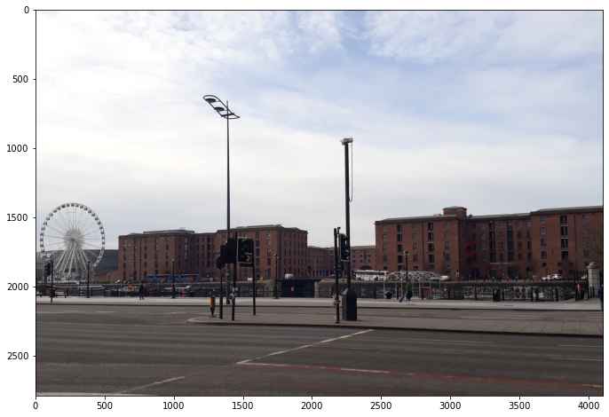

```python
## Displaying the picture
plt.figure(figsize=[12,8])
plt.imshow(image)
```

#### About the image

The image is a colour image that has data in 3 channels. The shape of the data - 2791 x 4103 x 3 - it is 2791 x 4103 matrix for each channel.

#### Splitting the Image in R, G, B Arrays

A digital colored image is a combination of R, G, and B arrays stacked over each other. It is needed to split each channel from the image and extract principal components from each of them.

R, G and B stands for red, green adn blue respectively.

```python
## Splitting the original image into blue, green and red arrays
blue,green,red = cv2.split(image)
```

#### Testing the image resolution by keeping different number of pricipal components

#### PCA with 25

```python
## Applying PCA to individual arrays

pca = PCA(25)

#Applying to red channel and then applying inverse transform to transformed array.
red_transformed = pca.fit_transform(red)
red_inverted = pca.inverse_transform(red_transformed)

#Applying to Green channel and then applying inverse transform to transformed array.
green_transformed = pca.fit_transform(green)
green_inverted = pca.inverse_transform(green_transformed)

#Applying to Blue channel and then applying inverse transform to transformed array.
blue_transformed = pca.fit_transform(blue)
blue_inverted = pca.inverse_transform(blue_transformed)
```

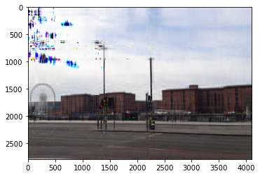

```python
## Compressing the image
img_compressed_25 = (np.dstack((blue_inverted, green_inverted, red_inverted))).astype(np.uint8)

## View compressed image
plt.imshow(img_compressed_25)
```

#### PCA with 100

```python
## Applying PCA to individual arrays

pca = PCA(100)

#Applying to red channel and then applying inverse transform to transformed array.
red_transformed = pca.fit_transform(red)
red_inverted = pca.inverse_transform(red_transformed)

#Applying to Green channel and then applying inverse transform to transformed array.
green_transformed = pca.fit_transform(green)
green_inverted = pca.inverse_transform(green_transformed)

#Applying to Blue channel and then applying inverse transform to transformed array.
blue_transformed = pca.fit_transform(blue)
blue_inverted = pca.inverse_transform(blue_transformed)
```

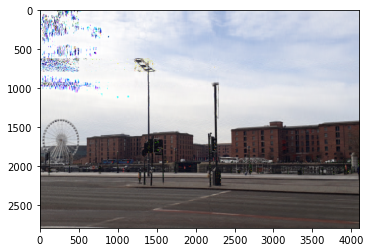

```python
## Compressing the image
img_compressed_100 = (np.dstack((blue_inverted, green_inverted, red_inverted))).astype(np.uint8)

## View compressed image
plt.imshow(img_compressed_100)
```

#### PCA with 300

```python
## Applying PCA to individual arrays

pca = PCA(300)

#Applying to red channel and then applying inverse transform to transformed array.
red_transformed = pca.fit_transform(red)
red_inverted = pca.inverse_transform(red_transformed)

#Applying to Green channel and then applying inverse transform to transformed array.
green_transformed = pca.fit_transform(green)
green_inverted = pca.inverse_transform(green_transformed)

#Applying to Blue channel and then applying inverse transform to transformed array.
blue_transformed = pca.fit_transform(blue)
blue_inverted = pca.inverse_transform(blue_transformed)
```

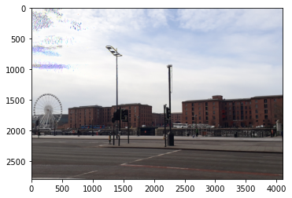

```python
## Compressing the image
img_compressed_300 = (np.dstack((blue_inverted, green_inverted, red_inverted))).astype(np.uint8)

## View compressed image
plt.imshow(img_compressed_300)
```

#### PCA with 700

```python
pca = PCA(700)

#Applying to red channel and then applying inverse transform to transformed array.
red_transformed = pca.fit_transform(red)
red_inverted = pca.inverse_transform(red_transformed)

#Applying to Green channel and then applying inverse transform to transformed array.
green_transformed = pca.fit_transform(green)
green_inverted = pca.inverse_transform(green_transformed)

#Applying to Blue channel and then applying inverse transform to transformed array.
blue_transformed = pca.fit_transform(blue)
blue_inverted = pca.inverse_transform(blue_transformed)
```

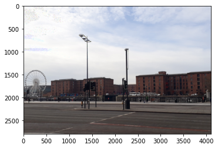

```python
## Compressing the image
img_compressed_700 = (np.dstack((blue_inverted, green_inverted, red_inverted))).astype(np.uint8)

## View compressed image
plt.imshow(img_compressed_700)
```

### Conclusion

#### References

Espirito Santo, Rafael. (2012). Principal Component Analysis applied to digital image compression. Einstein (São Paulo, Brazil). 10. 135-9. 10.1590/S1679-45082012000200004.

https://scikit-learn.org/stable/modules/decomposition.html#pca

https://towardsdatascience.com/dimensionality-reduction-for-machine-learning-80a46c2ebb7e

https://towardsdatascience.com/dimensionality-reduction-for-machine-learning-80a46c2ebb7e